# Hands On Analysis Chapter 5

Coder :Edouard Dewaerheijd (i6341571) & Presenter : Vienne Jetten (i6361245, Tutorial Group 3

2023-11-23

# Basics

Let’s start by importing are data set and necessary packages. Lets also include a quick summary of the data set to try and get a basic understanding of it.

```r
cereals <- read.csv("C:/Users/edewa/OneDrive/maastricht/year 1/Knowledge Discovery and Data Visualization/KDDV/tutorial 1/DatasetsLarose/cereals.CSV")
library(dplyr)
```

```r
library(ggplot2)
summary(cereals)
```

```
##      Name              Manuf               Type              Calories
##  Length:77          Length:77          Length:77          Min.   : 50.0
##  Class :character   Class :character   Class :character   1st Qu.:100.0
##  Mode  :character   Mode  :character   Mode  :character   Median :110.0
##                                                           Mean   :106.9
##                                                           3rd Qu.:110.0
##                                                           Max.   :160.0
##
##     Protein           Fat            Sodium          Fiber
##  Min.   :1.000   Min.   :0.000   Min.   :  0.0   Min.   : 0.000
##  1st Qu.:2.000   1st Qu.:0.000   1st Qu.:130.0   1st Qu.: 1.000
##  Median :3.000   Median :1.000   Median :180.0   Median : 2.000
##  Mean   :2.545   Mean   :1.013   Mean   :159.7   Mean   : 2.152
##  3rd Qu.:3.000   3rd Qu.:2.000   3rd Qu.:210.0   3rd Qu.: 3.000
##  Max.   :6.000   Max.   :5.000   Max.   :320.0   Max.   :14.000
##
##      Carbo          Sugars           Potass          Vitamins
##  Min.   : 5.0   Min.   : 0.000   Min.   : 15.00   Min.   :  0.00
##  1st Qu.:12.0   1st Qu.: 3.000   1st Qu.: 42.50   1st Qu.: 25.00
##  Median :14.5   Median : 7.000   Median : 90.00   Median : 25.00
##  Mean   :14.8   Mean   : 7.026   Mean   : 98.67   Mean   : 28.25
##  3rd Qu.:17.0   3rd Qu.:11.000   3rd Qu.:120.00   3rd Qu.: 25.00
##  Max.   :23.0   Max.   :15.000   Max.   :330.00   Max.   :100.00
##  NA's   :1      NA's   :1        NA's   :2
##      Shelf           Weight          Cups           Rating           Cold
##  Min.   :1.000   Min.   :0.50   Min.   :0.250   Min.   :18.04   Min.   :0.000
##  1st Qu.:1.000   1st Qu.:1.00   1st Qu.:0.670   1st Qu.:33.17   1st Qu.:1.000
##  Median :2.000   Median :1.00   Median :0.750   Median :40.40   Median :1.000
##  Mean   :2.208   Mean   :1.03   Mean   :0.821   Mean   :42.67   Mean   :0.961
##  3rd Qu.:3.000   3rd Qu.:1.00   3rd Qu.:1.000   3rd Qu.:50.83   3rd Qu.:1.000
##  Max.   :3.000   Max.   :1.50   Max.   :1.500   Max.   :93.70   Max.   :1.000
##
##     Nabisco            Quaker          Kelloggs       GeneralMills
##  Min.   :0.00000   Min.   :0.0000   Min.   :0.0000   Min.   :0.0000
##  1st Qu.:0.00000   1st Qu.:0.0000   1st Qu.:0.0000   1st Qu.:0.0000
##  Median :0.00000   Median :0.0000   Median :0.0000   Median :0.0000
##  Mean   :0.07792   Mean   :0.1039   Mean   :0.2987   Mean   :0.2857
##  3rd Qu.:0.00000   3rd Qu.:0.0000   3rd Qu.:1.0000   3rd Qu.:1.0000
##  Max.   :1.00000   Max.   :1.0000   Max.   :1.0000   Max.   :1.0000
##
##     Ralston            AHFP
##  Min.   :0.0000   Min.   :0.00000
##  1st Qu.:0.0000   1st Qu.:0.00000
##  Median :0.0000   Median :0.00000
##  Mean   :0.1039   Mean   :0.01299
##  3rd Qu.:0.0000   3rd Qu.:0.00000
##  Max.   :1.0000   Max.   :1.00000
##
```

Next let’s check for missing values before starting any type of analysis.

```r
#missing data?
missing_values <- sapply(cereals, function(x) sum(is.na(x)))
missing_values
```

```
##         Name        Manuf         Type     Calories      Protein          Fat
##            0            0            0            0            0            0
##       Sodium        Fiber        Carbo       Sugars       Potass     Vitamins
##            0            0            1            1            2            0
##        Shelf       Weight         Cups       Rating         Cold      Nabisco
##            0            0            0            0            0            0
##       Quaker     Kelloggs GeneralMills      Ralston         AHFP
##            0            0            0            0            0
```

We immediately notice that there is a couple of data points that are missing. one in “Carbo”, one in “sugars” and lastly two in “potass”. Since we are going to do quite a few regression models it is important to give values to those missing data points. The best solution in this case would be imputation with the mean. Here is how we did that:

```r
# Apply mean imputation to all numeric columns
cereals_clean <- cereals %>%
  mutate(across(where(is.numeric), ~ifelse(is.na(.), mean(., na.rm = TRUE), .)))
missing_data <- sum(is.na(cereals_clean))
cat("count of missing data :", missing_data)
```

```
## count of missing data : 0
```

Now that we have no more missing values let’s start the analysis.

# The Analyssis

Use the cereals data set included, at the book series website, for the following exercises. Use regression to estimate rating based on fiber alone.

## Question 11:

### What is the estimated regression equation?

```r
linear_regression_fiber <- lm(Rating ~ Fiber, data = cereals_clean)

# Display the regression summary to get the equation
summary(linear_regression_fiber)
```

```
##
## Call:
## lm(formula = Rating ~ Fiber, data = cereals_clean)
##
## Residuals:
##     Min      1Q  Median      3Q     Max
## -20.436  -8.159  -2.037   6.491  27.216
##
## Coefficients:
##             Estimate Std. Error t value Pr(>|t|)
## (Intercept)  35.2566     1.7674  19.948  < 2e-16 ***
## Fiber         3.4430     0.5524   6.233 2.45e-08 ***
## ---
## Signif. codes:  0 '***' 0.001 '**' 0.01 '*' 0.05 '.' 0.1 ' ' 1
##
## Residual standard error: 11.48 on 75 degrees of freedom
## Multiple R-squared:  0.3412, Adjusted R-squared:  0.3325
## F-statistic: 38.85 on 1 and 75 DF,  p-value: 2.445e-08
```

## Question 12:

### Explain clearly the value of the slope coefficient you obtained in the regression.

As established in question 11 the slope coefficient is 3.443. The coefficient is positive meaning that Fiber increases progressively . Furthermore, for each additional gram of fiber, the rating increases by approximately 3.44 points, holding all else constant. To finish of Fiber is statically significant since it’s t-score probability is less than 0.05.

## Question 13:

### What does the value of the y-intercept mean for the regression equation you obtained? Does it make sense in this example?

As established in question 11 the Y-intercept is 35.2566. it represents the predicted score for a cereal with 0 grams of fibers. The Y-intercept is statistically significant because the probability of it’s t value is under 0.05.

## Question 14

### What would be a typical prediction error obtained from using this model to predict rating? Which statistic are you using to measure this? What could we do to lower this estimatedprediction error?

The prediction error in a regression model is the difference between the observed values and the predicted values of the model. In this case it would be the difference between the observed rating of the cereal and the predicted rating of the regression model. To go farther, we use the Residual standard error (RSE for short). The RSE measures the typical size of the prediction errors. In the case of this linear regression model the RSE is 11.48. that means that on average the predicted variable is of by plus or minus 11.48 of the observed rating. to reduce the estimate prediction error, we could try and add more relevant variables to create a multiple linear regression model.

## Question 15

### How closely does our model fit the data? Which statistic are you using to measure this?

You can evaluate how well the model fits the data by using the R-squared statistic. In this case the R-squared is equal to 0.3412. this means that 34.12% of the variation in cereal rating is explained by it’s fiber content.

## Question 16

### Find a point estimate for the rating for a cereal with a fiber content of 3 grams.

```r
# Prediction for a cereal with 3 grams of fiber
predicted_rating <- predict(linear_regression_fiber, newdata = data.frame(Fiber = 3))

# Display the predicted rating
predicted_rating
```

```
##        1
## 45.58553
```

The estimated rating for 3 grams of fiber using are linear regression model is 45.58553 out 100.

## Question 17

### Find a 95% confidence interval for the true mean rating for all cereals with a fiber content of 3 grams.

```r
# 95% confidence interval for 3 grams of fiber
conf_interval <- predict(linear_regression_fiber, newdata = data.frame(Fiber = 3), interval = "confidence", level = 0.95)
conf_interval
```

```
##        fit      lwr      upr
## 1 45.58553 42.81792 48.35314
```

The 95% confidence interval for the true mean rating of cereals with 3 grams of fibers is between 42.818 and 48.353. This means that we are 95% confident that the average rating of all cerals with 3 grams of fibers lies in this range.

## Question 18

### Find a 95% prediction interval for a randomly chosen cereal with a fiber content of 3 grams

```r
# 95%  prediction interval for 3 grams of fiber
pred_interval <- predict(linear_regression_fiber, newdata = data.frame(Fiber = 3), interval = "prediction", level = 0.95)
pred_interval
```

```
##        fit      lwr      upr
## 1 45.58553 22.55513 68.61593
```

The 95% prediction intervals lies between 22.555 and 68.616. This means that we are 95% confident that the rating of any single cearal that contains 3 grams of fibers lies in this range.

## Question 19

### Based on the regression results, what would we expect a scatter plot of rating versus fiber to look like? Why?

Based on the regression results, we can say that there should be a positive and quite significant relationship between a cereal’s fiber content and its rating. The graph should be some what linear and trending up but a bit scattered at the same time because of variability.

but there is only one way to truly find out. let’s graph it:

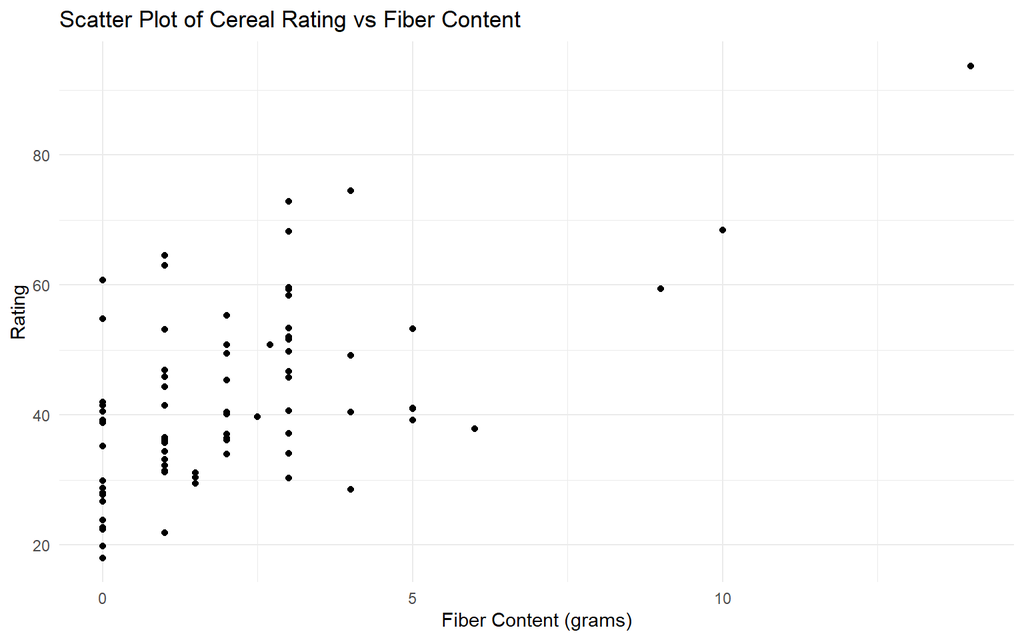

```r
ggplot(cereals_clean, aes(x = Fiber, y = Rating)) +
  geom_point() +
  labs(title = "Scatter Plot of Cereal Rating vs Fiber Content",
       x = "Fiber Content (grams)",
       y = "Rating") +
  theme_minimal()
```

In conclusion, not exactly linear but definitely up trending.

## Question 20

### What is the estimated regression equation?

```r
linear_regression_fiber_sugar <- lm(Rating ~ Fiber + Sugars, data = cereals_clean)

# Display the regression summary to get the equation
summary(linear_regression_fiber_sugar)
```

```
##
## Call:
## lm(formula = Rating ~ Fiber + Sugars, data = cereals_clean)
##
## Residuals:
##     Min      1Q  Median      3Q     Max
## -12.228  -4.471  -1.161   2.703  16.658
##
## Coefficients:
##             Estimate Std. Error t value Pr(>|t|)
## (Intercept)  52.2378     1.5563  33.566  < 2e-16 ***
## Fiber         2.8752     0.2981   9.644 1.02e-14 ***
## Sugars       -2.2429     0.1634 -13.731  < 2e-16 ***
## ---
## Signif. codes:  0 '***' 0.001 '**' 0.01 '*' 0.05 '.' 0.1 ' ' 1
##
## Residual standard error: 6.134 on 74 degrees of freedom
## Multiple R-squared:  0.8143, Adjusted R-squared:  0.8093
## F-statistic: 162.3 on 2 and 74 DF,  p-value: < 2.2e-16
```

The estimated regression equation would be:

**Rating = 52.2378 + 2.8752*Fiber - 2.2429*Sugars**

## Question 21

### Explain clearly and completely the value of the coefficient for fiber you obtained in the regression.

The coefficient for fiber is 2.8752. This indicates that for each gram of fiber in a certain cereal the value of the rating is expected to change by 2.88. This coefficient has a positive relationship with the rating variable. The fiber variable in this model is statistically significant because the probability of it’s T test is under 0.05.

## Question 22

### Compare the r² values from the multiple regression and the regression done earlier in the exercises. What is going on? Will this always happen?

The first model we made had a R-squared value of 0.3412 and the second model we build has a R-squared value of 0.8143. We can see that the second model is signifcantly bigger than the first one. This means that the addition of the variable “sugars” to the model significalty improved the model’s ability to explain the rating of cereals.

## Question 23

### Compare the s values from the multiple regression and the regression done earlier in the exercises. Which value is preferable, and why?

```r
# Extracting RSE from both models
rse_simple <- summary(linear_regression_fiber)$sigma
rse_multiple <- summary(linear_regression_fiber_sugar)$sigma

rse_simple
```

```
## [1] 11.47707
```

```r
rse_multiple
```

```
## [1] 6.134432
```

The RSE for the simple regression model is 11.47707 and the RSE for the multiple regression is 6.134432. By comparing these two we find out the multiple regression model is more acurate than the simple regression model. The addition of “sugars” as a variable has significantly diminished the RSE hens the models acuracy in general.